# Creating gsim containers

The first thing to do is to create a gsim container with the function `gsim()`. A container holds the simulations of your parameters as well as any relevant data, and executes operations on these objects. The first argument to gsim is the object containing simulations of parameters. This object can be:

- A Stan, Jags, or CODA object.
- Simulations created by `sim` from the ARM package. The simulations are saved in the container under the names `beta` and `sigma`.
- Fitted models (lm, glm, polr, lmer). Gsim then uses `arm::sim` to sample parameters from their estimated sampling distribution. In the case of `lmer` objects, the advantage of directly supplying the fitted model instead of ARM simulations is that gsim can work out the fitted values (in this case they are saved in the container under the name *fitted*).

The remaining arguments to gsim are objects containing data to be saved in the storage space of the container. These can be lists, data.frames and named numeric vectors or arrays. It is important that each object is named. An unnamed object will linger in the container in an invisible state.

# Bangladesh Wells example

In this vignette, we’ll first work with the Bangladesh Wells dataset described in [Gelman and Hill’s textbook](http://www.amazon.com/Analysis-Regression-Multilevel-Hierarchical-Models/dp/052168689X). This dataset can be retrieved using the `fetch_wells_data()` script. For simplicity, we’ll fit a classical logistic model and use a crude approximation of the posterior distribution of the parameters obtained through the `sim()` function from the ARM package.

```r
library(gsim)
wells_data <- fetch_wells_data()
wells_fit <- glm(switched ~ c_dist100 * c_arsenic, binomial, wells_data)
wells_sims <- gsim(wells_fit, wells_data, n_sims = 200)
```

In the last command, gsim sampled 200 simulations from the estimated sampling distribution of the parameters, and made the columns of `wells_data` available inside the container. Once the container is created, you can check its contents using `print()`, `summary()`, and `head()`.

```r
print(wells_sims)
```

```
## gsim container with:
##
## 2 parameters (beta, sigma) and 7 variables (educ, switched, assoc, dist, arsenic, c_dist100, c_arsenic)
```

## Posterior Predictive Check

Gsim is most useful to easily create statistical summaries depending on data and parameters that can be used to check the model. In this example, we’ll check for overdispersion of the residuals. The observed residual standard deviation is a relevant summary to check this aspect of the model. Computing this discrepancy measure is an ideal job for gsim because it depends on both the data and the parameters of the regression model. But even if the measure depended solely on the data, gsim can still be useful to sample replicates from the posterior predictive distribution (ppd) of the data. In this example, we’ll need to:

- Compute the fitted values. In general, fitted values are a by-product of the MCMC sampling procedure and will already be available along with the simulated parameters. Also, if we supplied a glmer model to gsim, it would have been able to retrieve the fitted values automatically. Here however, we need to compute them manually.
- Compute the observed residual standard deviation.
- Sample replicates from the ppd.
- Compute the residual standard deviation of the replicates.

We now illustrate the verbosity of the classical approach based on loops before turning to gsim code.

### Using loops

Here is the code needed to compute the ppc quantities with manual loops over simulations.

```r
n_sims <- 200
n_obs <- nrow(wells_data)

arm_sims <- arm::sim(wells_fit, n_sims)
X <- with(wells_data,
  cbind(rep(1, n_obs), c_dist100, c_arsenic, c_dist100 * c_arsenic)
)

fitted <- array(dim = c(n_sims, n_obs))
for (i in 1:n_sims) {
  fitted[i, ] <- inv_logit(X %*% cbind(arm_sims@coef[i, ]))
}

residuals <- sweep(fitted, 2, wells_data$switched, function(a, b) b - a)
residuals_var <- apply(residuals, 1, var)

y_rep <- array(dim = c(n_sims, n_obs))
residuals_rep <- array(dim = c(n_sims, n_obs))
for (i in 1:n_sims) {
  y_rep[i, ] <- rbinom(n_obs, 1, fitted[i, ])
  residuals_rep[i, ] <- y_rep[i, ] - fitted[i, ]
}
residuals_var_rep <- apply(residuals_rep, 1, var)

loop_p <- mean(residuals_var > residuals_var_rep)
```

Looping requires initializing the arrays and subsetting over the correct dimensions. Sometimes, we can use functionals such as `apply()` or `sweep()` to avoid looping, but this does not necessarily clarify the code. The verbosity of the code distracts the analyst from thinking about his modeling and checking tasks. Gsim aims to provide a framework for operating on parameters in which the distance between the code and the math is as small as possible.

### Using gsim

Gsim abstracts all the looping verbiage to let the user focus on the math. It also provides several helper functions to enhance code clarity (note that they all work outside gsim containers as well):

- The `intercept()` function constructs an intercept column. It examines the arguments of the surrounding function (here, `cbind()`) to figure out automatically the length of the vector of 1’s.
- The `inv_logit()` function to transform the linear predictor back to the scale of the outcome variable.
- The `col_vector()` wrapper to `cbind()` is a clearer semantic signal that you want to turn a vector into a column vector (an array of size n x 1). `row_vector()` is also available.
- The `rbernoulli()` wrapper to `rbinom()` makes the code a bit clearer. The whole dpqr family of functions is provided in gsim.

But the most clarifying feature of gsim is that array instantiation and looping are handled internally and transparently.

```r
out <- wells_sims({
  X <- cbind(intercept(), c_dist100, c_arsenic, c_dist100 * c_arsenic)
  fitted <- inv_logit(X %*% col_vector(beta))
  residuals <- switched - fitted
  residuals_sd <- sd(residuals)

  y_rep <- rbernoulli(3020, fitted)
  residuals_rep <- y_rep - fitted
  residuals_sd_rep <- sd(residuals_rep)

  comp <- residuals_sd > residuals_sd_rep
  summarise_sims(comp, mean)
})

out
```

```
## [1] 0.415
```

Two things are going on in the last statement. First, since it’s not an assignment statement, gsim returns the result (which we assigned to the variable `out`). Second, it **summarises** the simulations using the function provided in the second argument to `summarise_sims()`. In this case we simply took the mean over the simulations.

We have taken the posterior mean of the p-values, but we could have chosen the median or some quantiles. To facilitate this operation, gsim provides a shortcut by overloading the modulo operator.

```r
p <- wells_sims(comp %% median)
```

# Working with gsim

## Retrieving results

Each time an intermediate result is created, it is stored in the storage space of the container and can be reused or retrieved later. To retrieve a variable or a statement, just make sure that it is the last statement. Last statements will be returned invisibly. This means that you can’t see the result in the console if you just call gsim, but you still can assign it to a variable in your workspace.

If you want to retrieve several variables from your gsim container, you can use listed outputs. Also, gsim tries to produce outputs that are easy to work with in a data.frame format. We now review these two aspects.

### Listed outputs

You can pull out several variables at once by embedding them in a list. Inside a gsim container, `list()` uses non-standard evaluation to work out the names of the objects if you didn’t specify them manually.

```r
out <- wells_sims(list(p, y_rep))
names(out)
```

```
## [1] "p"     "y_rep"
```

### Tidy outputs

By default, gsim will transform any output with more than one dimension (i.e., everything except atomics and vectors) into data.frames. This makes it easy to interoperate with processing packages designed to work with this kind of data structures: `dplyr`, `tidyr`, `ggplot2`, `ggvis`, etc.

```r
beta <- wells_sims(beta)
class(beta)
```

```
## [1] "data.frame"
```

```r
head(beta)
```

```
##   sim      beta  value
## 1   1 intercept 0.3876
## 2   2 intercept 0.3211
## 3   3 intercept 0.3017
## 4   4 intercept 0.3501
## 5   5 intercept 0.3379
## 6   6 intercept 0.3470
```

Gsim uses non-standard evaluation to figure out good column names. When it cannot find an appropriate name, it uses the default *theta*. It is therefore important to choose appropriate object names and to avoid returning an operation without having first saved it a well named object. Here is an example of gsim resorting to a default name:

```r
out <- wells_sims(beta + beta)
names(out)
```

```
## [1] "sim"   "theta" "value"
```

The ‘long’ data.frame format is well suited for ggplot2. You can pivot on the variable *beta* to plot the posterior density of each coefficient in a facet grid.

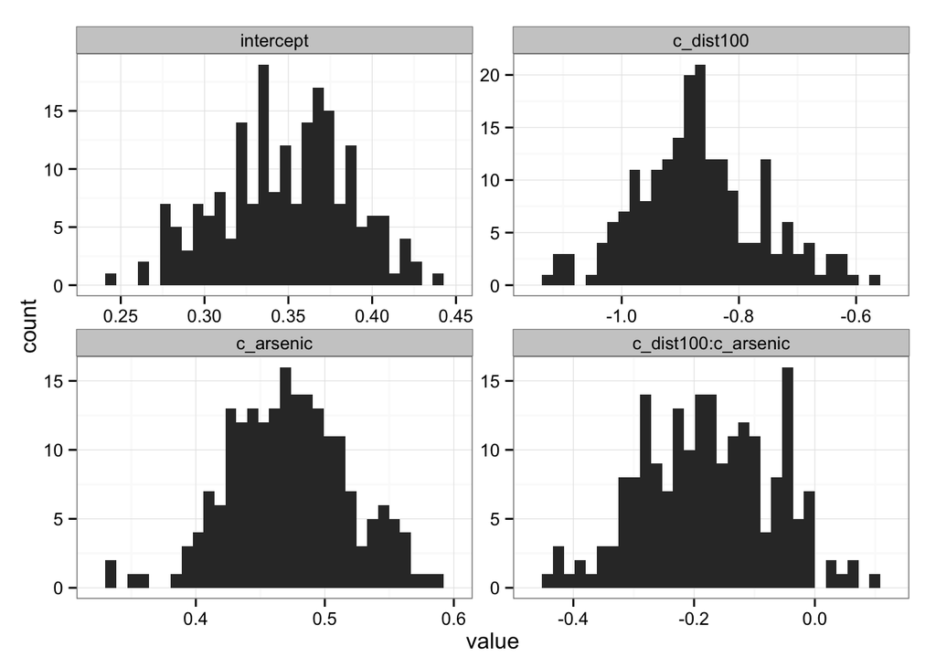

```r
library("ggplot2")
ggplot(beta, aes(value)) +
  geom_histogram() +
  facet_wrap(~ beta, scales = "free")
```

This behavior can be controlled in several ways:

- The transformation can be inhibited by wrapping the return statement with `I()`: `wells_sims(I(beta))` returns a matrix. The simulations always occupy the first dimension of the arrays returned by gsim.
- If you want gsim to always return arrays, you can set the `tidy_ouput` argument to FALSE when you create a container: `wells_sims <- gsim(wells_fit, tidy_output = FALSE)`. Then, you can selectively transform outputs to data.frames by wrapping the return statement with `T()`.

Note that `list()` trims the names from their modifiers.

```r
out <- wells_sims(list(I(beta), I(sigma)))
names(out)
```

```
## [1] "beta"  "sigma"
```

## Reusable statements

You can quote a statement or a group of statements and save the quote for later use. To save a single statement, just quote it:

```r
X_op <- quote(X <- cbind(intercept(), c_dist100, c_arsenic, c_dist100 * c_arsenic))
```

To save several statements, wrap them in curly braces before quoting them:

```r
sd_check_ops <- quote({
  fitted <- inv_logit(X %*% col_vector(beta))
  residuals <- switched - fitted
  residuals_sd <- sd(residuals)

  y_rep <- rbernoulli(3020, fitted)
  residuals_rep <- y_rep - fitted
  residuals_sd_rep <- sd(residuals_rep)
})
```

You then supply the quotes to a gsim container:

```r
wells_sims(X_op, sd_check_ops)
```

This can be useful to perform similar checks on different models. For example, you could create a second container with a different model including additional predictors. To perform the same check as before, only the design matrix *X* needs to be adapted.

A quoted statement can’t have a name that is already taken in the container. When a gsim container gets a name as an argument, it first checks inside its storage space. And only if it doesn’t find an object with this name will it check for a quoted statement in the calling environment.

# Reactive functions

## Basics

A nice feature is the ability to easily plot posterior summaries by creating reactive outputs. To give gsim the signal to create a reactive output, we specify inputs with `x()`, `y()` and `z()`. These inputs will become arguments in the reactive function.

```r
wells_sims2 <- gsim(wells_fit, wells_data)

fitted_fun <- wells_sims2({
  x <- x()
  X <- cbind(1, x, 2, x * 2)
  inv_logit(X %*% beta)
})
class(fitted_fun)
```

```
## [1] "function"     "reactive_fun"
```

```r
args(fitted_fun)
```

```
## function (x = NULL, out = "random", drop = "TRUE")
## NULL
```

Here we created a function which takes one argument, *x*. We could have added other arguments, for example by replacing the second predictor in the design matrix with `y()`. Each time you call this function with a new *x*, it recomputes the call stack using the new input value. Below, we compute the fitted values for a sequence of length 5 ranging from 0 to 2:

```r
sequence <- seq(0, 2, length.out = 5)
fitted_fun(sequence)
```

```
## [1] 0.8002 0.7097 0.5987 0.4765 0.3572
```

If we call the function a second time, the fitted sequence will be different. Indeed, the reactive function randomly chooses one simulation each time it is called.

```r
fitted_fun(sequence)
```

```
## [1] 0.7806 0.6235 0.4353 0.2641 0.1431
```

You can choose a specific simulation with the argument `out`. For example, `fitted_fun(sequence, out = 1)` will always return the same values, the ones corresponding to the first simulation of parameters.

## Plotting fitted models

You can also compute the fitted values over all simulations instead of just one, and summarise them with a function of your choosing. But keep in mind that this is an expensive operation if you have a lot of simulations and a long input sequence: the reactive function will have to repeat the computation `n_sims * length(sequence)` times. As an example, we’ll compute the posterior mean of the fitted values. To this end we provide the summarising function in the `out` argument:

```r
fitted_fun(sequence, out = mean)
```

```
## [1] 0.7838 0.6622 0.5150 0.3674 0.2436
```

This function can be put to good use to plot the fitted line repeatedly over different simulations to represent posterior uncertainty. In the snippet below, we use `replicate()` to call our reactive function repeatedly. We also draw the posterior mean in red.

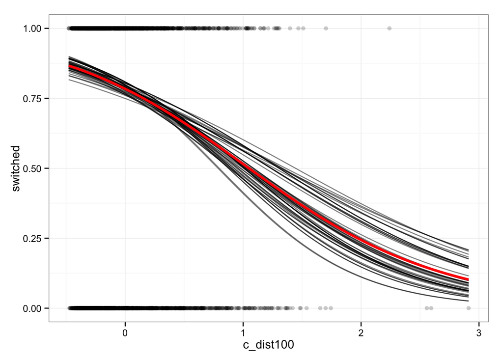

```r
ggplot(wells_data, aes(x = c_dist100)) +
  geom_point(aes(y = switched), alpha = 0.2) +
  replicate(50, stat_function(fun = fitted_fun, alpha = 0.5)) +
  stat_function(fun = fitted_fun, args = list(out = mean),
    color = "red", size = 1.2)
```

If you are a base graphics user, you can call `replicate(curve(fitted_fun, add = TRUE))` to produce the same spaghetti effect.

# Limitations

- If you copy a gsim container, its contents will not be duplicated. For example, after issuing `wells_sims_copy <- wells_sims`, the two objects will share the same content. Assigning or modifying a variable in *wells_sims_copy* will also take effect inside *wells_sims*. To effectively copy a container, use `clone()`, as in `wells_sims_copy <- clone(wells_sims)`.
- Currently, flow control statements will not work inside gsim (if, for, …).
- Subsetting parameters with square brackets may work, but has not been tested yet.